# SDGB-7844 Homework #4: Probability Distributions

Ryan Waffle

May 9, 2020

## The Geometric Probability Distribution & Weak Law of Large Numbers

Let us roll a $K$ sided die with numbers $1$, . . . , $K$ written on them where $K > 1$. Each number is equally likely to be rolled. Let $X$ be a random variable representing the number of rolls needed to get the number $K$ for the first time. (Note: number of rolls includes the roll where $K$ appears.)

1. On any roll, what is the probability of rolling the value $K$?

The probability of rolling the value of K is 1 / K

```r
# Setting K = 10
K <- 10
p_K <- (1/K)
p_K
```

```
## [1] 0.1
```

```r
rm(K)
```

2. What are all of the possible values of $X$?

3. Create a function with arguments, `K` and `n_sims`, with `n_sims` representing the number of times we should play out this scenario. Your function should return the number of times the die was rolled in order to get the value `K`. (Helpful hint: Try using a while loop)

```r
# Creating function named K_roll with arguments K and n_sims
k_roll <- function(K,n_sims){
  # Creating empty vector to hold the results from our function on the number of rolls to roll a K
  results <- rep(NA, times = n_sims)
  # Using a for loop to run simulations 1 to n_sims
  for(i in 1:n_sims){
    # Using variable to count the number of rolls to reach K
    roll_attempt <- 1
    # Using a while loop to run the simulation until the value of K is reached. If K is not met, the function continues to roll
    while(sample(1:K, size = 1, replace = TRUE) != K){
      # Adding 1 to the roll attempt to count the number of rolls until K is rolled
      roll_attempt <- roll_attempt + 1
    }
    # Adding the number of rolls to the vector created earlier
    results[i] <- roll_attempt
  }
  # Returning the results vector
  return(results)
}
```

4. For $K = [2, 6, 12, 15]$ simulate 100 rounds of the scenario and plot each set of results with a bar graph.

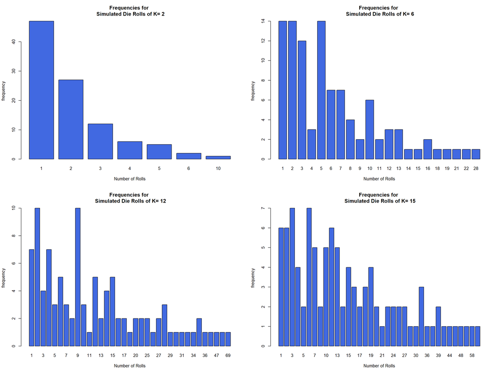

```r
# Creating a space for 4 plots
par(mfrow=c(2,2))

# USing the k_roll function with the K from the for loop and 100 sims and plotting to a histogram
for (K in c(2,6,12,15)){
  barplot(table(k_roll(K,100)), xlab="Number of Rolls", ylab="frequency",
        main=paste("Frequencies for \n Simulated Die Rolls of K=", K), col="royalblue")
}
```

5. Repeat question 4 by simulating 100 new rounds of each scenario and plot the results. Have your results changed? Please explain how they have changed. Why might your results be different?

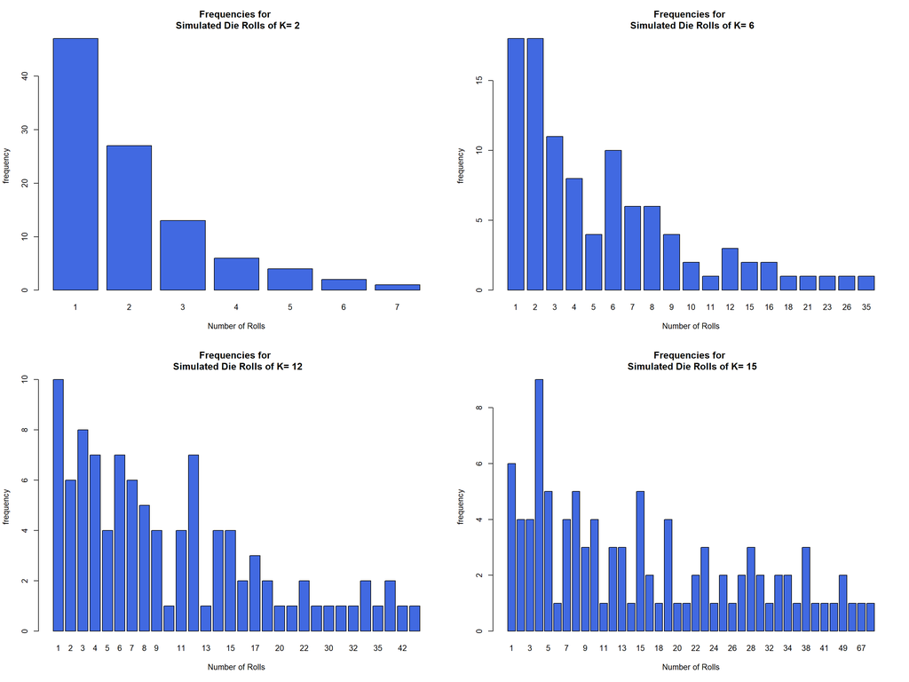

```r
# Repeating the previous step, to compare the results
par(mfrow=c(2,2))

for (K in c(2,6,12,15)){
  barplot(table(k_roll(K,100)), xlab="Number of Rolls", ylab="frequency",
        main=paste("Frequencies for \n Simulated Die Rolls of K=", K), col="royalblue")
}
```

6. For each combination of ``n_sim` = [100, 1000, 10000, 100000] and $K$ = [2, 6, 12, 15] calculate the average number of rolls required to get $K$. Show these results in a table where your columns are values of n_sim and your rows are values of $K$.

Average Number of Rolls to Reach K for Each Value of K and Number of Sims

|  | Sims = 100 | Sims = 1000 | Sims = 10000 | Sims = 100000 |
| --- | --- | --- | --- | --- |
| K = 2 | 1.97 | 2.029 | 1.9994 | 2.00046 |
| K = 6 | 5.83 | 6.134 | 5.9570 | 5.98242 |
| K = 12 | 12.54 | 12.344 | 11.9882 | 11.93159 |
| K = 15 | 16.18 | 15.746 | 15.2501 | 14.90947 |

7. How would you describe a general formula for calculating the average number of rolls?

For each value of K and number of sims, the average number of rolls is the sum of the number of the rolls divided by the number of simulations. So for K = 2 and n_sims = 1000, we will add up the number of rolls it took to reach K, and divide by the number of sims, 1000.

8. For $K$ = 6 and `n_sim` = 1000, estimate the following probabilities using your simulation function:

```r
# Creating empty vector for our probabilities
prob_results <- c()

# Calling our function and assigning to X_prob
X_prob <- k_roll(6, 1000)
# Creating for loop to find how many times a value occurs (1 through 6) in the vector from our function
for (i in 1:6){
  # Find the percentage that each number appears in X_prob
  p <- (length(which(X_prob == i)) / 1000)
  # Assigning to new vector
  prob_results <- c(prob_results, p)
}
# Adding 7 or greater to our vector by subtracting the sum of the previous vector from 1
prob_results <- c(prob_results, (1-sum(prob_results)))

# Creating dataframe from the vector, transposed
probabilities <- data.frame(t(prob_results))

# Changing row and column names
colnames(probabilities) <- c(1, 2, 3, 4, 5, 6, "7 or Greater")
rownames(probabilities) <- "P(X = x)"

# Using Kable for a better table
kable(probabilities [1,], caption = "Probabilities of Rolling Each Number")
```

Probabilities of Rolling Each Number

|  | 1 | 2 | 3 | 4 | 5 | 6 | 7 or Greater |
| --- | --- | --- | --- | --- | --- | --- | --- |
| P(X = x) | 0.174 | 0.148 | 0.106 | 0.091 | 0.071 | 0.075 | 0.335 |

9. In theory, is the probability $P(X = 500)$ > 0 when $K$ = 6? Explain.

In theory, yes, the probability can can be > ). Theoretically, there is an infinite number of possible rolls to reach the value of K. However, the probability is incredibly small, so practically this is not likely to happen.

10. Given that the probability mass function for the a geometric distributed random variable $X$ is
    $$P(X = x) = P( \overbrace{Fail, Fail,...,Fail}^{x-1}, Success) = qq...qp= q^{x-1}p$$
    Use the functions `dgeom()` and `pgeom()` to calculate the probabilites in question 8. For the `x` arguments, enter the outcomes `x-1` and your answer for #1 for the argument prob. (Hint: Check ?dgeom if you need help)

```r
#Theoretical probability for x =  1-6
theo6 <- dgeom((1:6)-1,1/6)

theo6
```

```
## [1] 0.16666667 0.13888889 0.11574074 0.09645062 0.08037551 0.06697960
```

```r
#Theoretical probability for x = 7
theo7plus <- pgeom(5, 1/6, lower.tail=FALSE)

#combining the vectors
theo <- c(theo6, theo7plus)
```

11. Create a figure with two plots side by side: The first plot of the empirical probability mass function estimate based on the data simulated in #8 (histogram is acceptable - use `prob=TRUE`). The second plot should plot the theorical probability mass function for our data in #10.

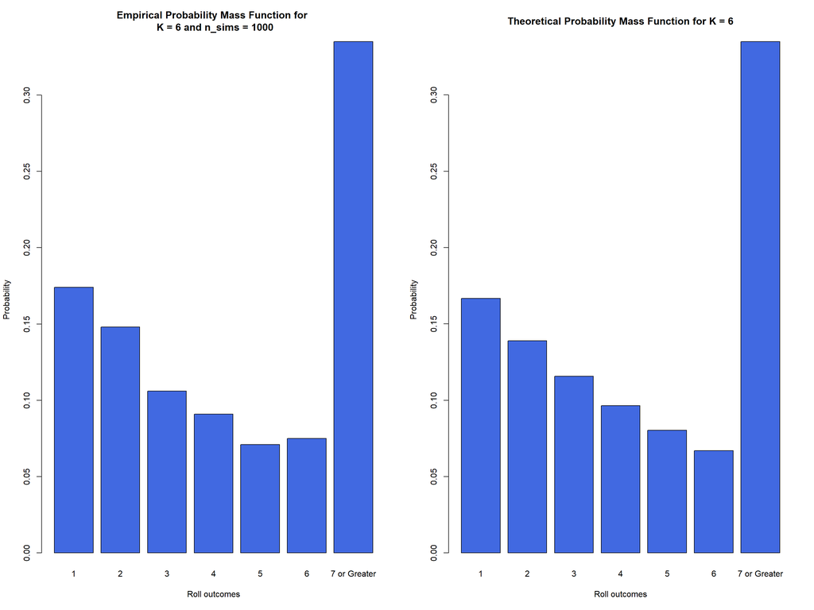

```r
par(mfrow=c(1,2))
# Creating Empirical PMF for our simulated data
barplot(prob_results, xlab="Roll outcomes", ylab="Probability", names.arg=c("1", "2", "3", "4", "5", "6", "7 or Greater"), main="Empirical Probability Mass Function for \n K = 6 and n_sims = 1000", col="royalblue")

# Creating Theoretical PMF for our simulated data
barplot(theo, xlab="Roll outcomes", ylab="Probability", names.arg=c("1", "2", "3", "4", "5", "6", "7 or Greater"), main="Theoretical Probability Mass Function for K = 6", col="royalblue")
```

12. How close are your answers from your simulation to the probabilities from the geometric distribution you just created? Describe this given what we’ve learned about the Weak Law of Large Numbers in lecture 8. What parameters need to change in our function in order for our empirical probabilities to match the theoretical values for $(X=x)$

13. For $K$ = 6, and `n_sim` = [1 - 50000] (Hint: use a for loop) plot the mean of each sample as a line graph. Add a horizontal line at the theorical mean (6). What is your observation of this relationship between n_sim and the mean of our sample?

[figure not shown]

```r
# Creating empty vector to hold results of this simulation
results <- c()

# Using For loop to run for simulation sizes 1 through 5000
for (z in c(1:5000)){
  # Calling our functioning and adding the mean of each simulation into the results vector
  results <- c(results, mean(k_roll(6,z)))
}

# Plotting the result in a line graph
plot(results, main="Price by Reviews Per Month", xlab="Num Simulations", ylab="Mean of Sample", pch=1, las=TRUE)
# Adding the theoretical mean of 6 as a red line
abline(h=6, col="red")
legend("topright", legend = "Theoretical Mean", col = "red", lty = 1:2)
```

As the number of simulations/sample size increases, the mean of the of the function gets closer to the theoretical mean of 6.

14. For $K$ = 6, what is the probability that it takes more than 12 rolls to roll a 6?

```r
# Use pgeom to find proability of 12+ rolls, setting lower.tail to false
theo12plus <- pgeom(10, 1/6, lower.tail=FALSE)
theo12plus
```

```
## [1] 0.134588
```

15. For $K$ = 6, what is the probability that you roll a 6 in your first three rolls?

```r
# Using pgeom to find the probability within first 3 rolls
rolls_3 <- pgeom(2, (1/6))
rolls_3
```

```
## [1] 0.4212963
```

16. For $K$ = 6, what is the 95th percentile for number of rolls required to roll a 6?

```r
# Use qgeom to find 95th percentile where k=6
pct_95 <- qgeom(p=0.95, prob=(1/6))
pct_95
```

```
## [1] 16
```

## The Exponential Probability Distribution & Central Limit Theorem

The magnitude of earthquakes in North America can be modeled as having an exponential distribution with mean $\mu$ of 2.4.

For an *exponential distribution*:

**Mean:** $\mathbb{E}[X] = {\lambda}$

**Variance:** $\mathbb{E}[X^2] - (\mathbb{E}[X])^2 = \lambda^2$

18. Simulate 1000 earthquakes and plot the distribution of Richter Scale values (Hint: `rexp(x, rate = 1/lambda)`). Let this data represent $X$. Create a histogram of $X$ and describe the shape of this distribution. How does this differ from the normal distribution?

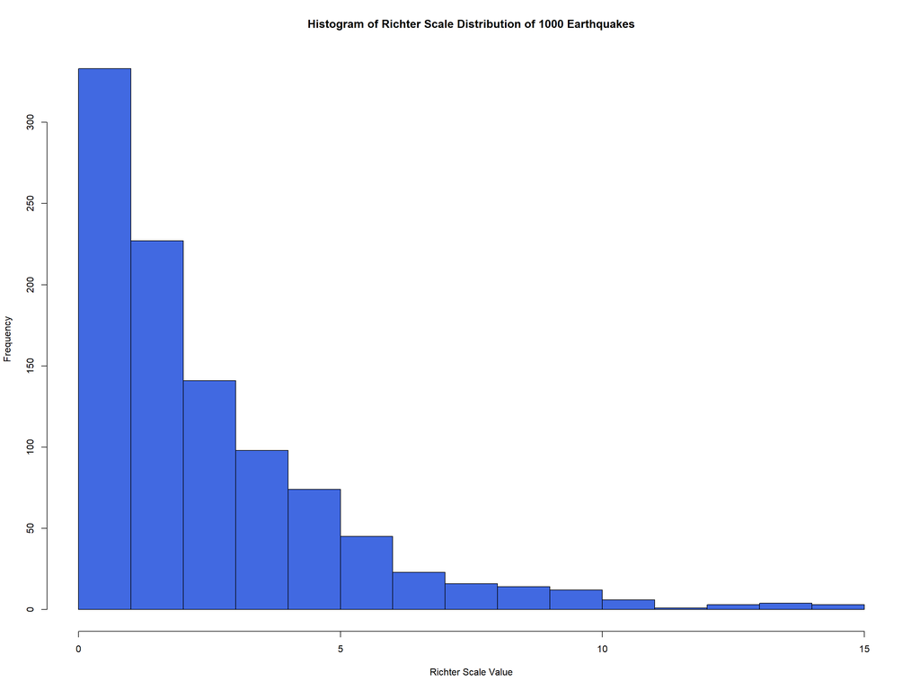

```r
# Simulating using rexp, 1000 rolls and lambda = 2.4
quakes <- rexp(1000, rate = (1/2.4))
# Plotting histogram of quakes vector based on rexp
hist(quakes, freq = TRUE, main="Histogram of Richter Scale Distribution of 1000 Earthquakes", xlab="Richter Scale Value", col="royalblue")
```

Normal distribution has a bell curve shape. This distribution contains higher values as you get closer to zero, and lower values the further away from zero.

19. Find the probability that an earthquake occurring in North America will fall between 2 and 4 on the Richter Scale.

```r
# Using dexp to find probability of 2-4 for earthquakes based on lambda 2.4
quake <- dexp((2:4)-1,1/2.4)
# Adding probability to get total probability from 2 to 4
sum(quake)
```

```
## [1] 0.5751432
```

20. How rare is an earthquake with a Richter Scale value of greater than 9?

```r
# Using pexp to find probability greater than 9 on Richter scale
quake9plus <- pexp(7, 1/2.4, lower.tail=FALSE)
quake9plus
```

```
## [1] 0.05411377
```

21. Create a function which will simulate multiple samples drawn from an exponential distribution with $\lambda$ = 2.4 (Hint: `rexp(x, rate = 1/lambda)` and return a vector containing the mean values for each of your samples. Your arguments should be lamba, n_sims for the number of simulations per sample, and n_samples for the number of samples of size n_sims to be created.

```r
# Defining distribution function
quake_distro <- function(lambda, n_sims, n_samples){
  # Creating Dataframe to hold mean values for each sample
  quake_results <- rep(NA, times = n_samples)
  # For loop to run from 1 through the simulations
  for (i in 1:n_sims){
    # Assigning mean exponential distribution values to variable x
    x <- rexp(n_samples, (1/lambda))
    # Adding to dataframe previously created
    quake_results[i] <- mean(x)
    rm(x)
  }
  # Returning exp_results vector
  return(quake_results)
}
```

22. Use your function with arguments `lambda` = 2.4, `n_sim` = 1000, `n_samples` = 40 to create a vector of mean values of Richter Scale readings. Let $\bar{X}$ represent this data. Plot a histogram of the data. Describe the distribution of $\bar{X}$. Is $\bar{X}$ distributed differently than $X$?

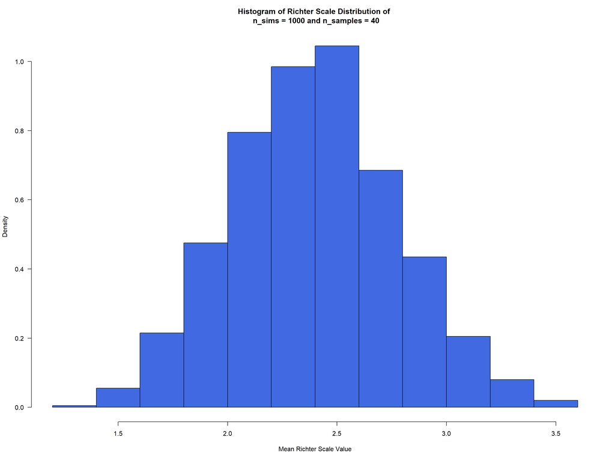

```r
# Setting values of lambda, n_sims and n_samples
lambda <- 2.4
n_sims <- 1000
n_samples <- 40

# running function and assigning to variable X_bar, with our new variables in the arguments
X_bar <- quake_distro(lambda, n_sims, n_samples)
# Creating histogram based on X_Bar
hist(X_bar, freq=FALSE, las=TRUE, main="Histogram of Richter Scale Distribution of \n n_sims = 1000 and n_samples = 40", xlab="Mean Richter Scale Value", col="royalblue")
```

X_bar has a distribution that appears to be a normal distribution, with a bell curve. X had a more exponential curve, with a higher value the closer you get to zero.

23. Calculate the sample mean and sample variance for the data simulated in #18. Calculate the population variance given $\lambda$ = 2.4.

```r
# Calculating Sample Mean
sample_mean <- mean(quakes)
sample_mean
```

```
## [1] 2.457219
```

```r
# Calculating Sample variance which is sample_mean squared
sample_variance <- sample_mean ^2
sample_variance
```

```
## [1] 6.037926
```

```r
# Calculating theoretical mean which is lambda squared
theo_variance <- lambda ^2
theo_variance
```

```
## [1] 5.76
```

24. Create a plot of $\bar{X}$. Make sure to set `prob=TRUE` in the `hist()` function. Include vertical lines for the sample and theoretical mean values (red = sample mean, blue = theoretical mean).

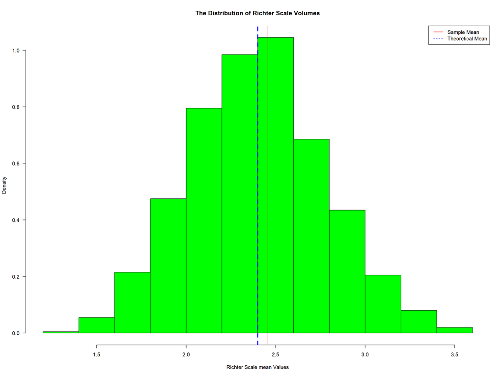

```r
# Creating Histogram based on X_bar variable from function
hist(X_bar, las = TRUE, col = "green", prob = TRUE, main = "The Distribution of Richter Scale Volumes", xlab = "Richter Scale mean Values")
# Adding two lines > Sample Mean and Theoretical Mean
abline(v = c(sample_mean, lambda), col = c("red", "blue"), lty=c(1,2), lwd=c(1,3))
legend("topright", legend = c("Sample Mean", "Theoretical Mean"), col = c("red", "blue"), lty = 1:2)
```

25. Add lines to our plot of $\bar{X}$ to plot the density for both our simulated sample and theoretical population (Hint: use `dnorm(x, mean=lambda, sd=(lambda/sqrt(n_samples))` to calculate theorical population density). Make sure to set `prob=TRUE` in the `hist()` function.

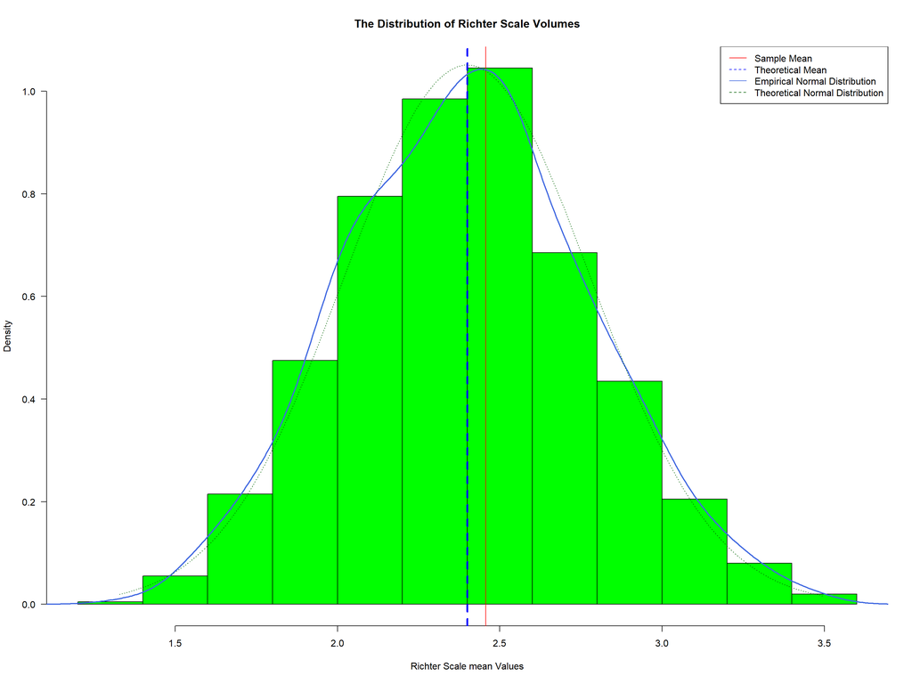

```r
#Readding histogram from previous question
hist(X_bar, las = TRUE, col = "green", prob = TRUE, main = "The Distribution of Richter Scale Volumes", xlab = "Richter Scale mean Values")
abline(v = c(sample_mean, lambda), col = c("red", "blue"), lty=c(1,2), lwd=c(1,3))

# Add empirical distribution for mean
lines(density(X_bar), col = "royalblue", lwd=2)

# Add theoretical normal distribution for mean
curve(dnorm(x, mean = lambda, sd = (lambda/sqrt(n_samples))), from = min(X_bar), to = max(X_bar), add = TRUE, lty = "dotted", col = "darkgreen")

legend("topright", legend = c("Sample Mean", "Theoretical Mean", "Empirical Normal Distribution", "Theoretical Normal Distribution"), col = c("red", "blue", "royalblue", "darkgreen"), lty = 1:2)
```

26. The Central Limit Theorem states that if you take many repeated samples from a population, and calculate the averages or sum of each one, the collection of those averages will be normally distributed. Does the shape of the distribution of $X$ matter with respect to the distribution of $\bar{X}$? Is this true for all **any** parent distribution of $\bar{X}$?

No, the shape of the distribution should not matter. Since X_bar is looking at the average values of distributions, as long as the sample size is large enough, the collection of those averages should result in a normal distribution.

27. What will happen to the distribution of $\bar{X}$ if you re-run your function with arguments `lambda` = 2.4, `n_sim` = 10000, `n_samples` = 40? How does the variance of $\bar{X}$ change from our data simulated for $\bar{X}$ in #25? Create a figure with the histograms (`prob=TRUE`) for both of our $\bar{X}$ sampling distributions. Explain the difference in the two distributions of $\bar{X}$

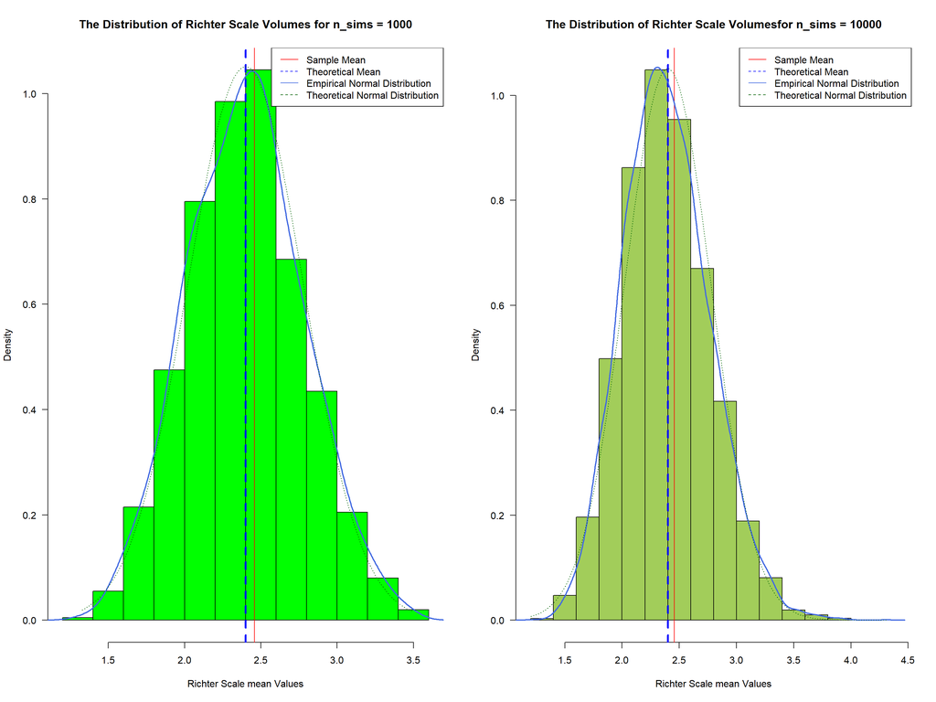

```r
par(mfrow=c(1,2))
#Readding histogram from previous question
hist(X_bar, freq = FALSE, las = TRUE, col = "green", prob = TRUE, main = "The Distribution of Richter Scale Volumes for n_sims = 1000", xlab = "Richter Scale mean Values")
abline(v = c(sample_mean, lambda), col = c("red", "blue"), lty=c(1,2), lwd=c(1,3))

# Add empirical distribution for mean
lines(density(X_bar), col = "royalblue", lwd=2)

# Add theoretical normal distribution for mean
curve(dnorm(x, mean = lambda, sd = (lambda/sqrt(n_samples))), from = min(X_bar), to = max(X_bar), add = TRUE, lty = "dotted", col = "darkgreen")

legend("topright", legend = c("Sample Mean", "Theoretical Mean", "Empirical Normal Distribution", "Theoretical Normal Distribution"), col = c("red", "blue", "royalblue", "darkgreen"), lty = 1:2)

# Creating new vector from our function, but with n_sims = 10000
z <- quake_distro(lambda, 10000, n_samples)

# Creating new histogram based on new distribution

hist(z, freq = FALSE, las = TRUE, col = "darkolivegreen3", prob = TRUE, main = "The Distribution of Richter Scale Volumesfor n_sims = 10000", xlab = "Richter Scale mean Values")
abline(v = c(sample_mean, 2.4), col = c("red", "blue"), lty=c(1,2), lwd=c(1,3))

# Add empirical distribution for mean
lines(density(z), col = "royalblue", lwd=2)

# Add theoretical normal distribution for mean
curve(dnorm(x, mean = lambda, sd = (lambda/sqrt(n_samples))), from = min(z), to = max(z), add = TRUE, lty = "dotted", col = "darkgreen")

legend("topright", legend = c("Sample Mean", "Theoretical Mean", "Empirical Normal Distribution", "Theoretical Normal Distribution"), col = c("red", "blue", "royalblue", "darkgreen"), lty = 1:2)
```

There is very little difference between the two distributions. As our samples get larger, the mean will be normally distributed based on the sample size. However, since we are not increasing the sample size, only the number of times the simulations will run, the distributions of X_bar will remain relatively steady. If we were to change n_samples, for example from 40 to 400, we would see the distributions change.